# Ecology and the biosphere

## Things to Know (#s)

- **#Round, Tilted, Spinning Earth**
- **#Climate Control**
- **#What Makes a Biome**
- **#Species Where/Why**

## Ecology:

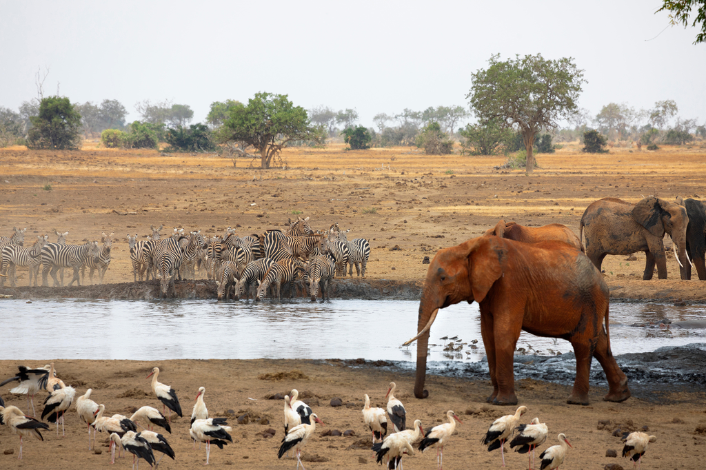

## The big picture: Earth’s climate controls species distributions

- **Ecology can be measured at many different levels**
  - individual → ecosystem → biosphere
- **The environment regulates where species can be**
  - What regulates the environment?
- **Earth is divided up into different biomes**
  - control the distribution of species
  - climate defines these life zones
- **Abiotic *and* biotic factors determine where species can exist**

[figure not shown]

## What is climate?

- **Climate:**
  - i.e. temperature, precipitation, sunlight, atmospheric pressure, & wind
  - often long-term averages (e.g., 30 years)
- **Global climate depends on the amount of energy received by the sun and how that energy flows through the biosphere (e.g., atmosphere, living things).**
  - different regions can have different climates.
  - different regions may have seasons, where climate fluctuates
  - global climate has had major shifts in geologic time via ice ages, global events
  - human activities now alter climate patterns via shifts in atmospheric chemistry

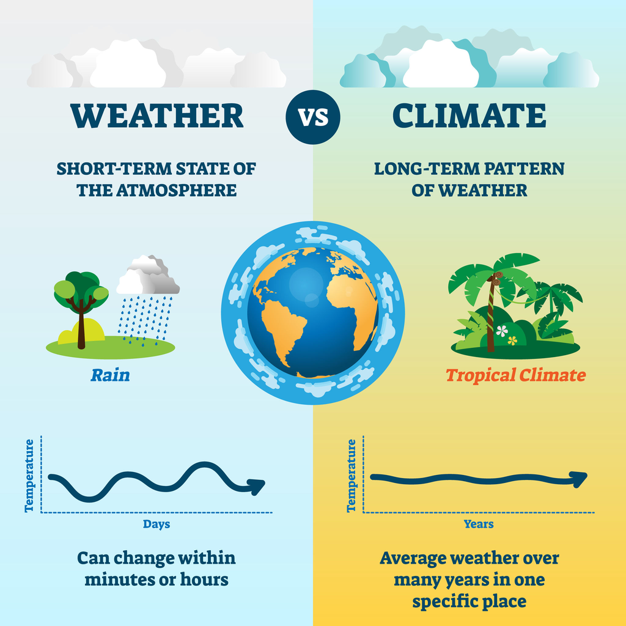

## What is climate?

- **Requires measurements of weather conditions at thousands of locations every day of the year**
  - observations used to quantify long-term average conditions

[figure not shown]

## Climate is driven by the sun’s energy, which varies by latitude

- **Solar energy (sun) heats the air, land, & water**
  - impacts temperature
  - impacts air movement (wind patterns)
  - impacts evaporation (adds water vapor into atmosphere)
- **Earth is round, sun radiation strikes unevenly**
  - strikes directly @ equator
  - more diffuse (spread out) towards poles
- **Uneven surface heating alters climate across latitudes**
  - relation north or south of the Earth’s equator

[figure not shown]

## Climate also varies by season

- **Earth is titled & spinning as it circles sun**
  - impacts day length
  - impacts amount of solar energy
  - impacts temperature
- **Climates within a latitude may change during the year due to this tilt**
  - seasons
  - wind and ocean currents
- **Seasonal variation smallest at equator**
  - increases towards poles

[figure not shown]

## Climate zones exist by latitude

**Combinations of hot/cold, wet/dry, seasons/no seasons**

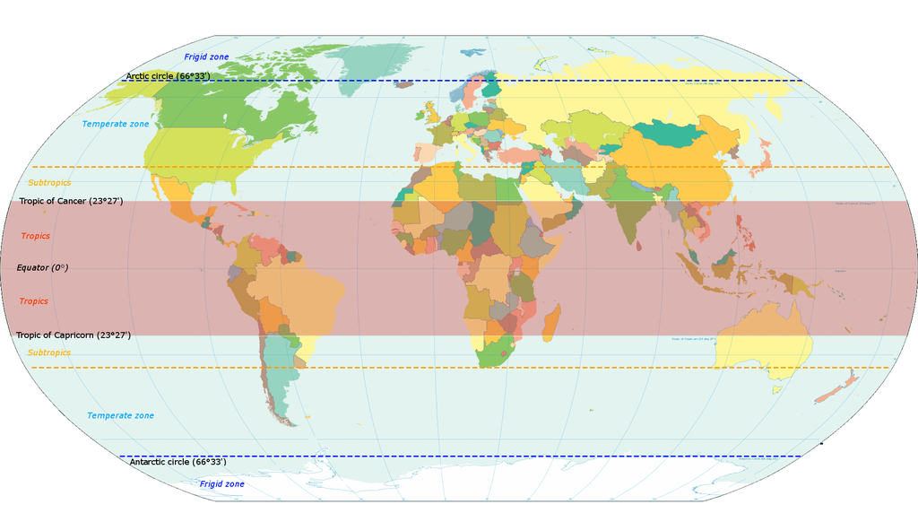

## Bodies of water play a huge role in climate

- **Oceans are heat conveyor belts**
  - water absorbs lot of heat in tropical zones
  - currents move them
  - heat/cool air masses via evaporation/condensation
- **Impacts climate of land**
  - heat energy can be deposited on land

[figure not shown]

## Climate patterns distribute life on Earth

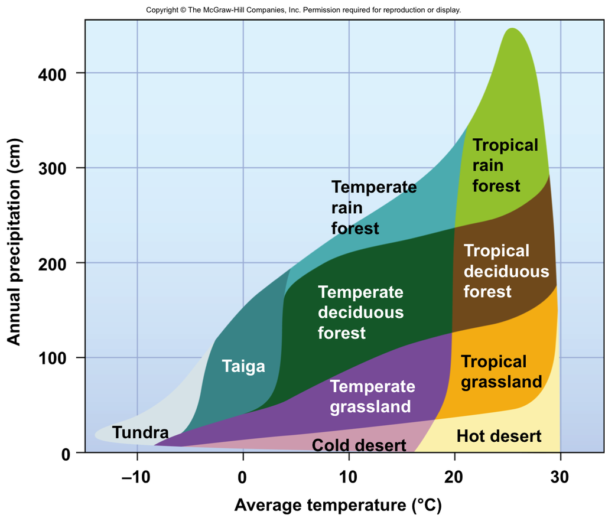

- **Major zones of vegetation are called *biomes***
  - tropics → desert → tundra
- **Biome locations are defined by temperature and precipitation**
  - annual averages
  - seasonal variation
- **Why do areas of N. America, with similar annual averages of climate factors, support *either* deciduous trees or evergreen trees?**

## Distribution of terrestrial biomes

[figure not shown]

## What makes a biome a biome?

- **Biomes named for:**
1. physical features (polar ice)
2. climate features (tropical / temperate)
3. vegetation (grassland / broad-leaf forest)
- **Each contains organisms adapted for the specific environment**
  - animals, plants, fungi, etc
- **Boundaries between biomes are not firm**
  - *ecotones*: areas of overlap

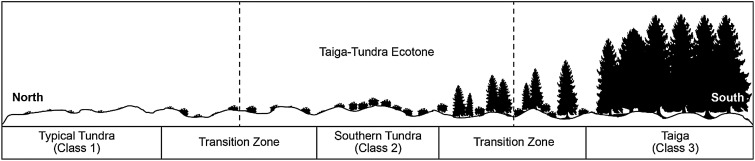

## Aquatic biomes are also diverse

- **Characterized by physical and chemical environment**
  - fresh vs saltwater
  - depth of light penetration
- **Oceans cover 3/4 of Earth’s surface**
  - evaporation fuels rainfall
  - algae and bacteria supply O<sub>2</sub>
  - regulate global temperature and wind
- **Aquatic biomes linked to terrestrial neighbor**
  - inputs impact water chemistry
  - related climate

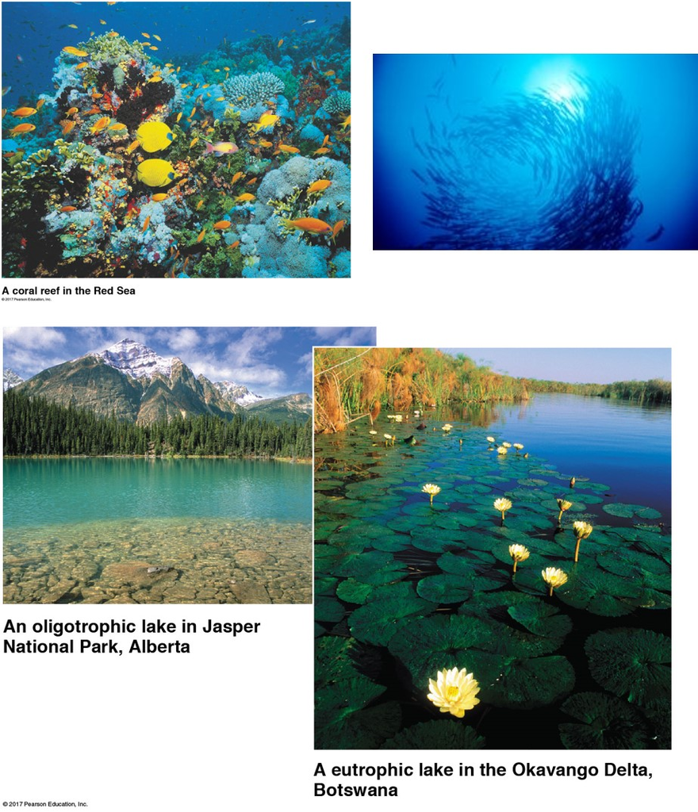

## Species distributions: Where and Why?

- **Species distributions are part ecology & part evolution**
- **Why are kangaroos only in Australia?**
- **Why are different kangaroos in some habitats but not others?**
  - abiotic (non-living) factors…
  - biotic (living) factors…

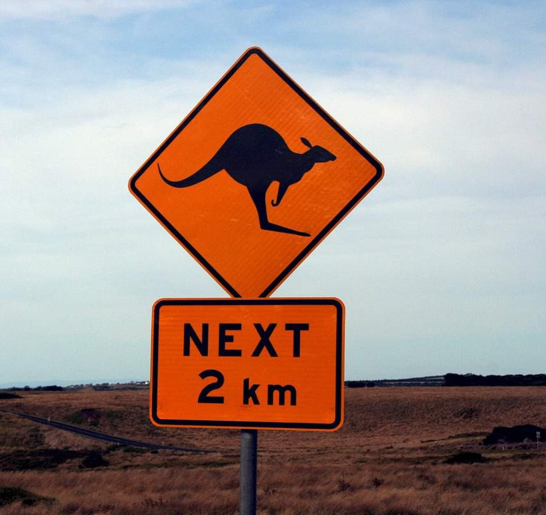

## Kangaroos evolved only in Australia

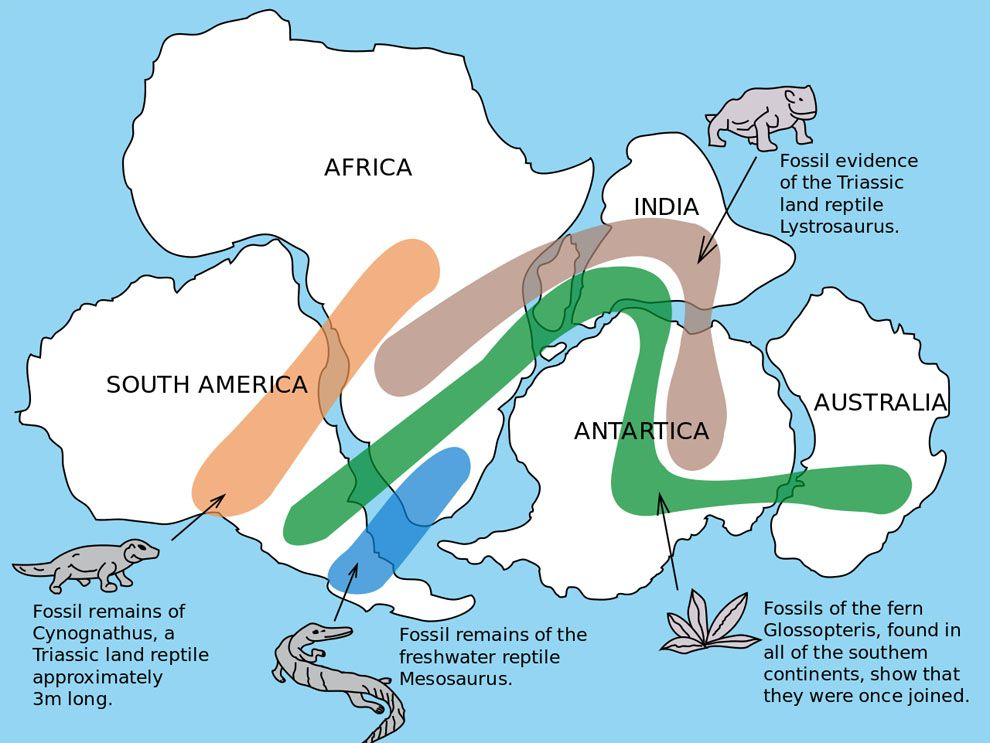

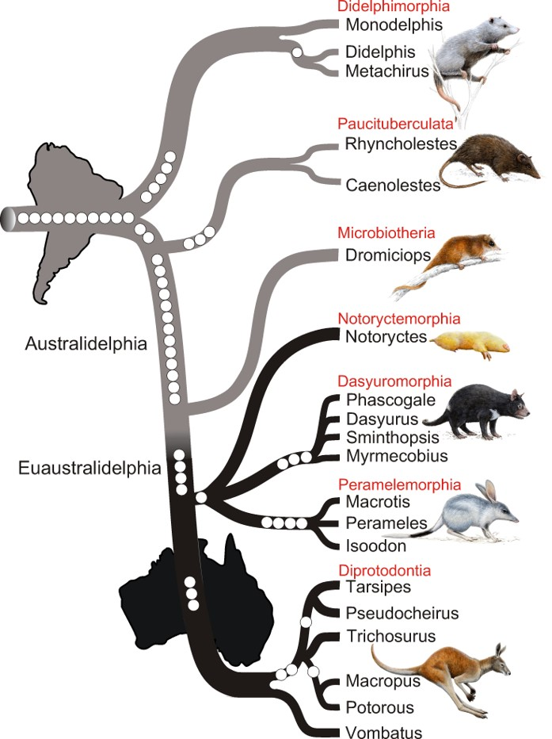

## *Dispersal* keeps kangaroos in Australia (mostly)

- **Dispersal:**
  - limits the distribution of a species
- **Some organisms can disperse widely**
  - which ones?
  - kangaroos cannot
  - humans are unnatural dispersers
- **Geographic isolation is key to evolution**

[figure not shown]

## Different Kangaroo species are adapted to different climates

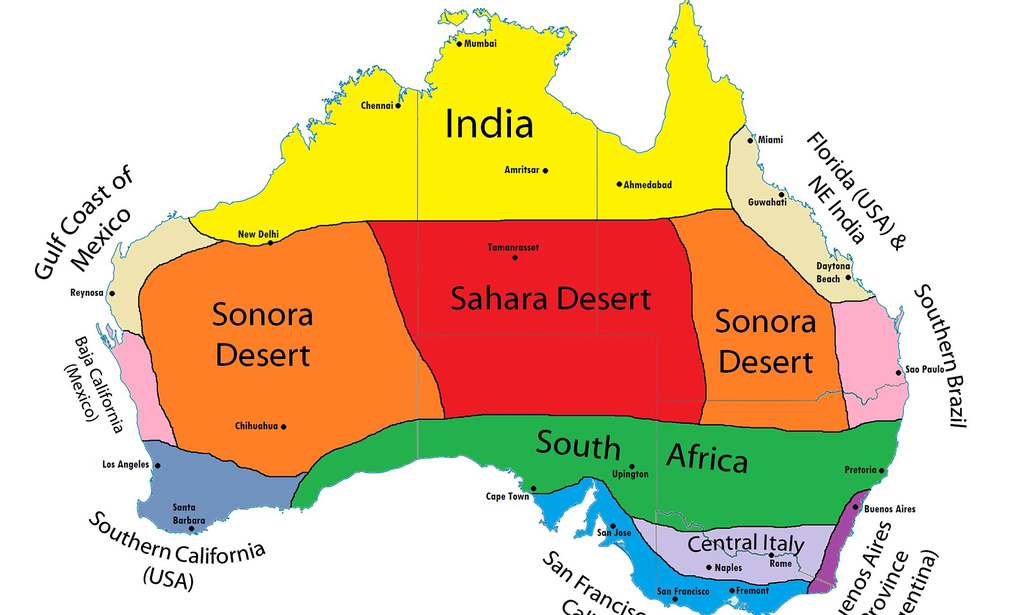

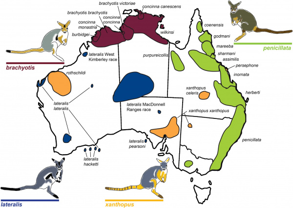

## Abiotic limitations to Red Kangaroo distribution

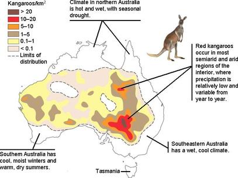

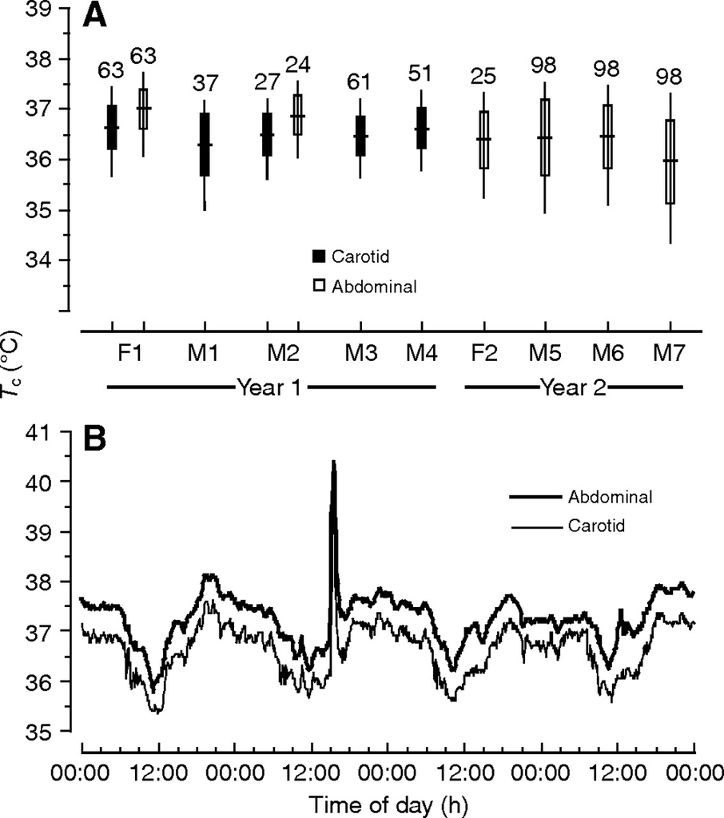

## Biotic limitations to kangaroo distribution (competition)

[figure not shown]

[figure not shown]

## Where can a species exist?

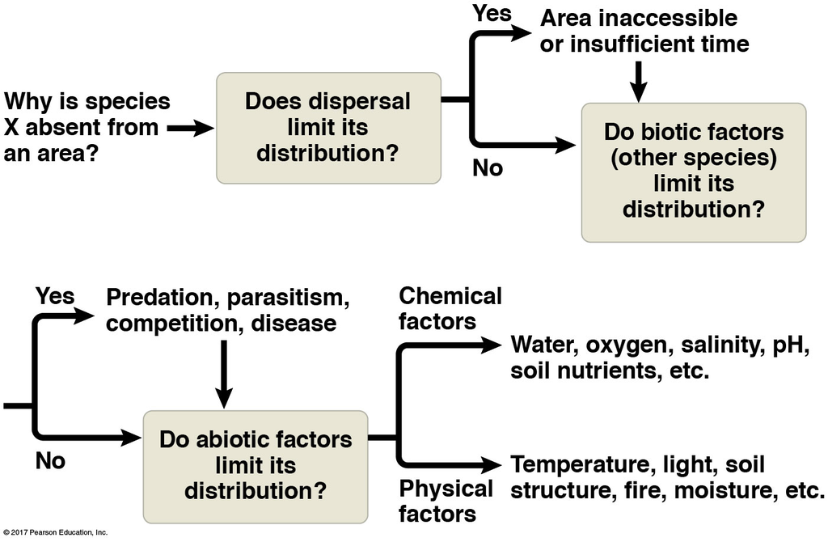